# Activity prediction

## Overview

Using devices such as Jawbone Up, Nike FuelBand, and Fitbit it is now possible to collect a large amount of data about personal activity relatively inexpensively. These type of devices are part of the quantified self movement - a group of enthusiasts who take measurements about themselves regularly to improve their health, to find patterns in their behavior, or because they are tech geeks. One thing that people regularly do is quantify how much of a particular activity they do, but they rarely quantify how well they do it. In this project, our goal is to use data from accelerometers on the belt, forearm, arm, and dumbell of 6 participants. Six young health participants were asked to perform one set of 10 repetitions of the Unilateral Dumbbell Biceps Curl in five different fashions: exactly according to the specification (Class A), throwing the elbows to the front (Class B), lifting the dumbbell only halfway (Class C), lowering the dumbbell only halfway (Class D) and throwing the hips to the front (Class E).T he goal of this project is to predict the manner in which they did the exercise.

## Data loading and exploratory analysis

First we load training and testing datasets.

```r
library(randomForest)
library(caret)
setwd("C:/Users/keeton/Desktop/C9-Machine Learning/")
training <- read.csv(file = "pml-training.csv", sep = ",", na.strings = "NA",
                     header=TRUE)
testing <- read.csv(file = "pml-testing.csv", sep = ",", na.strings = "NA",
                    header = TRUE)
```

Dataset has 19622 observations in 160 variables. There are many entries in this dataset thus we check columns for missing values. Table with percent of NAs for each variable can be found at fig.1 (see Appendix). There are many variables which contain mostly NAs. Thus next step will be data clearing.

```r
preds <-subset(names(training),
               grepl("^yaw|^pitch|^roll|^magnet|^accel|^gyros",names(training)),)
subTraining <- training[,preds]
```

We have used regular expression to select columns without NAs. These variables are candidates for predictors. Now we has only 48 variables, but it is still possible to reduce this number. We will use singular value decomposition to exclude variables with low variation.

```r
svdTrain <- svd(subTraining)
```

Consider first right singular vector (fig.2). Many values are just about zero, thus corresponding columns explain low portion of total variation and can be discarded. We have excluded variables with corresponding 1-st RSV value less than 0.1.

```r
preds <- preds [which(abs(svdTrain$v[,1])>=0.1)]
```

## Modelling

We have selected random forest algorithm with $k$-fold cross-validation. Assume $k = 10$. To limit computational time we have set number of trees $n=100$

```r
preds <- paste(preds, sep="")
formula <- as.formula(paste("classe ~ ", paste(preds, collapse= "+")))
k=10
n=100
folds <- createFolds(y=training$classe, k=k, list=TRUE)
res <- numeric(k)

for (i in 1:k) {
  kTraining <-training[-folds[[i]],]
  kTesting <- training[folds[[i]],]
fit <- randomForest(formula,data=kTraining,ntree=n)
predict <- predict(fit,newdata=kTesting)
res[i] <- sum(kTesting$classe == predict) /nrow(kTesting)
}

table(predict,kTesting$classe)
```

```
##
## predict   A   B   C   D   E
##       A 547  11   6   6   3
##       B   2 350   7   3   2
##       C   6  11 323  11   5
##       D   3   3   2 297   4
##       E   0   5   4   4 347
```

```r
mean(res)
```

```
## [1] 0.9455209
```

## Appendix

**Figure 1. Percent of NAs for each variable**

```
##                        X                user_name     raw_timestamp_part_1
##                0.0000000                0.0000000                0.0000000
##     raw_timestamp_part_2           cvtd_timestamp               new_window
##                0.0000000                0.0000000                0.0000000
##               num_window                roll_belt               pitch_belt
##                0.0000000                0.0000000                0.0000000
##                 yaw_belt         total_accel_belt       kurtosis_roll_belt
##                0.0000000                0.0000000                0.0000000
##      kurtosis_picth_belt        kurtosis_yaw_belt       skewness_roll_belt
##                0.0000000                0.0000000                0.0000000
##     skewness_roll_belt.1        skewness_yaw_belt            max_roll_belt
##                0.0000000                0.0000000                0.9793089
##           max_picth_belt             max_yaw_belt            min_roll_belt
##                0.9793089                0.0000000                0.9793089
##           min_pitch_belt             min_yaw_belt      amplitude_roll_belt
##                0.9793089                0.0000000                0.9793089
##     amplitude_pitch_belt       amplitude_yaw_belt     var_total_accel_belt
##                0.9793089                0.0000000                0.9793089
##            avg_roll_belt         stddev_roll_belt            var_roll_belt
##                0.9793089                0.9793089                0.9793089
##           avg_pitch_belt        stddev_pitch_belt           var_pitch_belt
##                0.9793089                0.9793089                0.9793089
##             avg_yaw_belt          stddev_yaw_belt             var_yaw_belt
##                0.9793089                0.9793089                0.9793089
##             gyros_belt_x             gyros_belt_y             gyros_belt_z
##                0.0000000                0.0000000                0.0000000
##             accel_belt_x             accel_belt_y             accel_belt_z
##                0.0000000                0.0000000                0.0000000
##            magnet_belt_x            magnet_belt_y            magnet_belt_z
##                0.0000000                0.0000000                0.0000000
##                 roll_arm                pitch_arm                  yaw_arm
##                0.0000000                0.0000000                0.0000000
##          total_accel_arm            var_accel_arm             avg_roll_arm
##                0.0000000                0.9793089                0.9793089
##          stddev_roll_arm             var_roll_arm            avg_pitch_arm
##                0.9793089                0.9793089                0.9793089
##         stddev_pitch_arm            var_pitch_arm              avg_yaw_arm
##                0.9793089                0.9793089                0.9793089
##           stddev_yaw_arm              var_yaw_arm              gyros_arm_x
##                0.9793089                0.9793089                0.0000000
```

[output cut: 53 more lines]

```
##                0.0000000                0.0000000                0.9793089
##         avg_roll_forearm      stddev_roll_forearm         var_roll_forearm
##                0.9793089                0.9793089                0.9793089
##        avg_pitch_forearm     stddev_pitch_forearm        var_pitch_forearm
##                0.9793089                0.9793089                0.9793089
##          avg_yaw_forearm       stddev_yaw_forearm          var_yaw_forearm
##                0.9793089                0.9793089                0.9793089
##          gyros_forearm_x          gyros_forearm_y          gyros_forearm_z
##                0.0000000                0.0000000                0.0000000
##          accel_forearm_x          accel_forearm_y          accel_forearm_z
##                0.0000000                0.0000000                0.0000000
##         magnet_forearm_x         magnet_forearm_y         magnet_forearm_z
##                0.0000000                0.0000000                0.0000000
##                   classe
##                0.0000000
```

**Figure2. First right singular vector for training dataset**

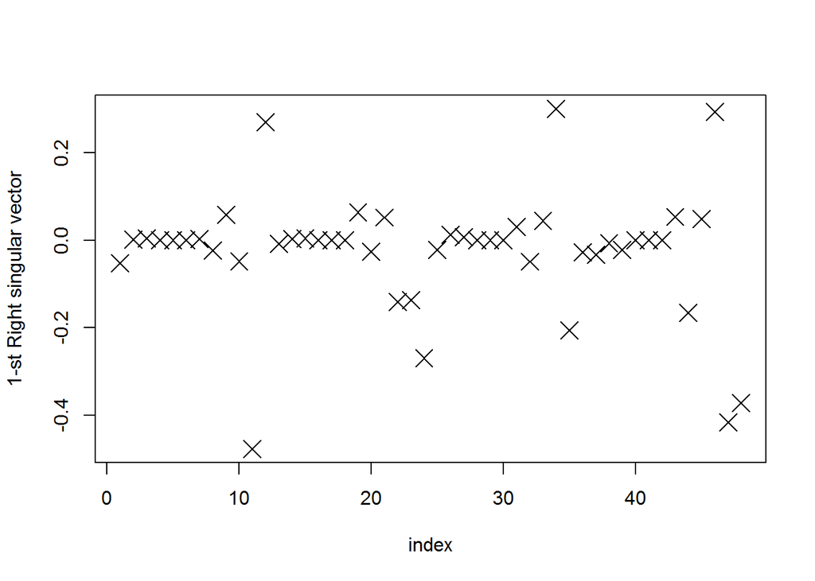